# Assignment04

Qi Xue - qx61

October 10, 2021

## Data source

World Bank Geocoded Research Release, Version 1_4_2 [data](https://www.aiddata.org/data/world-bank-geocoded-research-release-level-1-v1-4-2)

```r
knitr::opts_chunk$set(message = FALSE)
knitr::opts_chunk$set(warning = FALSE)

#install.packages("sf")
#install.packages("treemapify")

library(tidyverse)
```

```r
library(ggplot2)
library(treemapify)
```

```r
project <- read_csv("projects.csv")
locations <- read_csv("locations.csv")
ancillary <- read_csv("projects_ancillary.csv")
```

# Graph 1 - Project commitments over 1995-2014

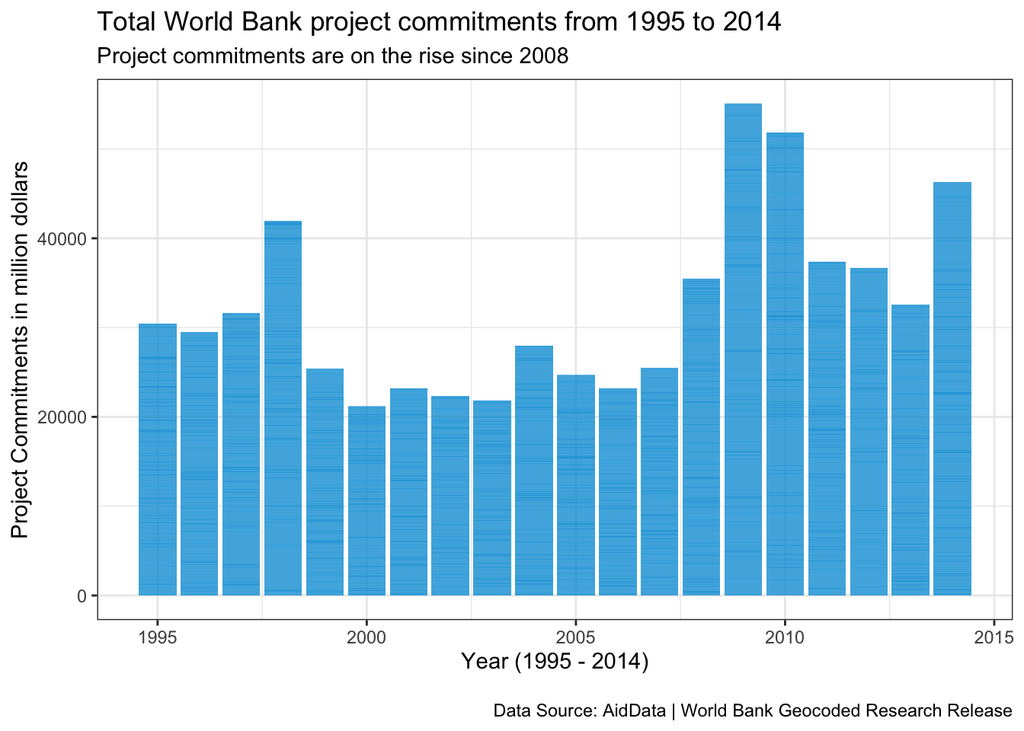

```r
project %>%
  mutate(year = as.numeric(substring(start_actual_isodate, 1, 4))) %>%
  mutate(m_total_commitments = total_commitments/1000000) %>%
  ggplot(aes(x = year, y = m_total_commitments)) +
  geom_col(fill = "#009FDA", alpha = 0.8) +
  theme(plot.margin = unit(c(1, 1, 1, 1), "cm")) +
  theme_bw() +
  labs(title = paste("Total World Bank project commitments from 1995 to 2014"),
       subtitle = paste("Project commitments are on the rise since 2008"),
       x = "Year (1995 - 2014)",
       y = "Project Commitments in million dollars",
      caption = "\nData Source: AidData | World Bank Geocoded Research Release")
```

```r
ggsave(filename = "project_commitments.png")
```

World Bank project commitments remained relatively stable before 2008. Yet, year 1998 saw a spike in investment may possibly be due to the Asian financial crisis. Project spending also rose after the 2008 financial crisis, and fluctuated more than in previous periods. We see a more active role for the World Bank not only investing in long-term results but crisis response.

# Graph2 - Gap between commitments and reimbursements

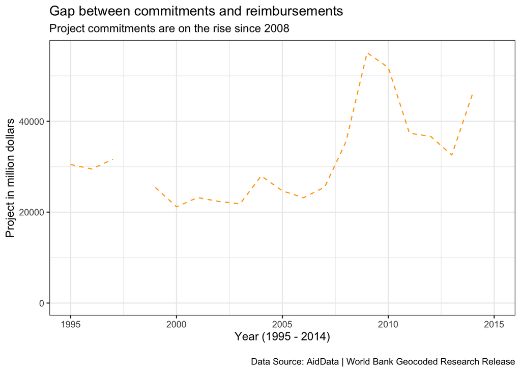

```r
project %>%
   mutate(m_total_commitments = total_commitments/1000000,
          m_total_disbursements = total_disbursements/1000000,
          year = as.numeric(substring(start_actual_isodate, 1, 4))) %>%
   group_by(year) %>%
   summarize(n_m_total_commitments = sum(m_total_commitments), na.rm = TRUE,
             n_m_total_disbursements = sum(m_total_disbursements), na.rm = TRUE) %>%
   ggplot(aes(x = year)) +
   geom_line(aes(y = n_m_total_disbursements),
             group = 1, color = "blue") +
   geom_line(aes(y = n_m_total_commitments),
             linetype = "dashed", color = "orange") +
   theme_bw() +
   scale_x_continuous(limits = c(1995, 2015),
                     breaks = c(1995, 2000, 2005, 2010, 2015)) +
   scale_y_continuous(limits = c(0, NA)) +
   labs(title = paste("Gap between commitments and reimbursements"),
       subtitle = paste("Project commitments are on the rise since 2008"),
       x = "Year (1995 - 2014)",
       y = "Project in million dollars",
      caption = "\nData Source: AidData | World Bank Geocoded Research Release")
```

```r
ggsave(filename = "commitments_gap.png")
```

This line graph intends to see the gap between project commitments and disbursements. We would be interested know how the World Bank is balancing of its project budget. Further, we could learn more about when and where projects experience with the largest gaps in funding. However, due to some issues, the disbursements line cannot be shown, limiting our ability to make conclusions or inference.